[figure not shown]

Contents lists available at ScienceDirect

Journal of Functional Foods

journal homepage: www.elsevier.com/locate/jff

[figure not shown]

Prebiotic effect of dietary polyphenols: A systematic review

Aline Medeiros Alves-Santos, Clara Sandra Araújo Sugizaki, Glaucia Carielo Lima,

Maria Margareth Veloso Naves<sup>⁎</sup>

*School of Nutrition, Federal University of Goiás (UFG), Goiânia, Goiás, Brazil*

A R T I C L E I N F O

*Keywords:*

Gut microbiota

Health

Beneficial bacteria

Butyric acid

Phenolic compounds

Metabolites

A B S T R A C T

Prebiotics are substrates selectively metabolized by hindgut microorganisms conferring health benefits. Recent

studies suggest polyphenols as candidate to prebiotics. Thus, this systematic review aimed to investigate the

prebiotic effect of dietary polyphenols in preclinical and clinical studies. Animal studies demonstrated that the

consumption of polyphenols, especially catechins, anthocyanins and proanthocyanidins, increases the abun-

dance of *Lactobacillus*, *Bifidobacterium*, *Akkermansia*, *Roseburia*, and *Faecalibacterium* spp. Moreover, polyphenols

supplementation increased the production of short-chain fatty acids (SCFA), including butyrate. The included

clinical trials showed an increased abundance of *Lactobacillus acidophilus*, *Bifidobacterium* and *Faecalibacterium*

spp., and a reduction in plasma lipopolysaccharide-binding protein after the consumption of anthocyanins and

ellagic acid. In conclusion, there is strong evidence in preclinical studies that dietary polyphenols can stimulate

both the growth of microorganisms identified as prebiotic targets and an increase in the production of SCFA.

Therefore, clinical trials are warranted to investigate the prebiotic effect of dietary polyphenols on humans.

**1. Introduction**

Prebiotics are defined as substrates selectively utilized by the host's

microorganisms resulting in benefits for metabolic health, gastro-

intestinal system, bone health and mental health. Some dietary fibers,

especially resistant oligosaccharides (inulin, fructo-oligosaccharides

and galacto-oligosaccharides), are well-recognized in literature as pre-

biotics (Gibson et al., 2017). Besides dietary fibers, recent studies have

shown the interaction between polyphenols and the gut microbiota,

suggesting them as candidate compounds to prebiotics (Sanders,

Merenstein, Reid, Gibson, & Rastall, 2019; Shortt et al., 2018; Singh,

Cabral, Kumar, Ganguly, & Pandey, 2019).

Polyphenols are secondary metabolites of plants, characterized by

aromatic rings bearing one or more hydroxyl groups in their chemical

structure, ranging from that of a simple phenolic molecule to that of a

complex high-molecular mass polymer (Mojzer et al., 2016). These

compounds have low bioavailability and extensive metabolism in the

large intestine, favoring interactions with intestinal microorganisms

(Bian, Wei, Zhao, & Li, 2020). Actually, there is a bidirectional inter-

action, in which polyphenols modulate the gut microbiota and, con-

versely, microorganisms can modulate the activity of the phenolic

compounds. This interaction can regulate the metabolism and the

bioavailability of polyphenols, converting them into metabolites, which

may have different effects on the host health (Singh et al., 2019).

Dietary polyphenols are associated with a reduced risk of cardio-

metabolic diseases when regularly consumed (Noad et al., 2016). Stu-

dies show that polyphenols have antioxidant, anti-inflammatory (Chai,

Davis, Zhang, Zha, & Kirschner, 2019), anti-obesogenic, antilipidemic

(Fang et al., 2019) and anti-diabetic (Paquette et al., 2017) activities.

However, the role of dietary polyphenols in health largely depends on

their metabolism, absorption and bioavailability processes which are, in

turn, related to the gut microbiota modulation, in terms of composition

and functionality. Although polyphenols are currently recognized as

modulators of the gut microbiota composition, there is still no con-

clusive evidence of their prebiotic effect (Cueva, Silva, Pinillos,

Bartolomé, & Moreno-Arribas, 2020). The prebiotic effect of each

polyphenol can be influenced by the food source and the chemical

structure of the compound, along with the individual differences in the

gut microbiota composition (Serreli & Deiana, 2019). Therefore, es-

tablishing a relationship among the polyphenols consumption, the

growth of microorganisms recognized as prebiotic targets, the meta-

bolites generated and the effect on health is somewhat of a challenge.

This systematic review aimed to investigate the available evidence of

the prebiotic effect of dietary polyphenols.

https://doi.org/10.1016/j.jff.2020.104169

Received 29 June 2020; Received in revised form 17 August 2020; Accepted 19 August 2020

⁎ Corresponding author at: School of Nutrition, UFG, Rua 227, Setor Leste Universitário, 74605-080 Goiânia, Goiás, Brazil.

*E-mail addresses:* alinemedeiros@ufg.br (A.M. Alves-Santos), maria_margareth_veloso@ufg.br (M.M.V. Naves).

Journal of Functional Foods 74 (2020) 104169

1756-4646/ ©

2020 The Authors. Published by Elsevier Ltd. This is an open access article under the CC BY-NC-ND license

(http://creativecom

m

ons.org/licenses/BY-NC-ND/4.0/).

[figure not shown]

**2. Material and methods**

*2.1. Search strategy and study selection*

In accordance with the Preferred Reporting Items for Systematic

Reviews and Meta-Analyses (PRISMA) guidelines (Moher et al., 2015),

a systematic literature search was carried out through the PubMed,

Scopus and Web of Science databases up to August 02, 2019, using

terms related to prebiotic, gut microbiota and polyphenols (Table 1).

After the removal of duplicates using a bibliographic reference man-

ager, two authors independently reviewed the titles and abstracts of

each paper identified in the search. This procedure was performed

using a systematic review software. The selected studies were retrieved

for full-text analysis and eligible articles were identified. Afterwards,

they were reanalyzed for details of the study design and their outcome

to select the papers included in this review. Any disagreements in this

regard were solved by the means of discussion with a third author.

*2.2. Inclusion and exclusion criteria*

The following criteria were applied for inclusion: (1) a randomized

controlled study design using animals and/or humans; (2) intervention

with either isolated polyphenol or food extract; (3) phenolic com-

pounds profile of the food extract available; (4) outcomes related to

changes in the gut microbiota composition, with stimulation of mi-

croorganisms

recognized

as

prebiotic

targets

(*Lactobacillus,*

*Bifidobacterium, Roseburia, Eubacterium,* and *Faecalibacterium* spp.)

(Gibson et al., 2017), including the *Akkermansia* spp. (Sanders et al.,

2019), and/or an increase in the production of short-chain fatty acids

(SCFA), including butyrate; and (5) publishing in English. Studies with

a lower than eight number of animals per group, acute studies, drug-

induced pathologies, gut microbiota composition assessment by culture

plate methods, and without the microorganism genera identification

were excluded.

*2.3. Data extraction*

The included studies were reviewed and the following data were

abstracted: sample source, exposure dosage, animal model or study

population (subjects and sample size), intervention period, diet type,

outcomes related to gut microbiota and host health, paper’s first author

and date of publication.

*2.4. Quality assessment*

The quality assessment of animal studies was conducted using the

SYRCLE’s risk of bias tool (Hooijmans et al., 2014). Cochrane Colla-

boration's tool (Higgins et al., 2011) was used for the quality assessment

of clinical trials.

**3. Results**

*3.1. Description of studies*

The initial search strategy yielded 4025 articles, out of which 1685

were excluded as duplicates. After analysis of titles and abstracts, 2044

records were excluded, including *in vitro* studies, review articles, con-

ference abstracts, letters, protocols, editorials, and unavailable full-

texts, and 296 were selected for full-text review. Among these, 242

studies were excluded according to the exclusion criteria. Thus, full-text

review of 54 eligible studies were made, excluding 30 articles for dif-

ferent reasons: there was no growth of microorganisms recognized as

prebiotic targets (Casanova-Marti et al., 2018; Cheng, Chen, Zhang,

et al., 2019; Cires et al., 2019; Collins et al., 2016; Cowan et al., 2014;

González-Sarrías et al., 2017; Griffin et al., 2017; Guo, Tang, et al.,

2018; Li, Liu, Liu, Liao, & Zou, 2019; Most, Penders, Lucchesi,

Goossens, & Blaak, 2017; Porras et al., 2017; Remely et al., 2017; Shen,

Wan, Wang, & Jiang, 2019; Sung et al., 2017; Tan et al., 2018; Unno &

Osakabe, 2018; Wang et al., 2019; Yu et al., 2019; Yuan et al., 2018;

Zhang, Dong, et al., Zhang, Zhang, et al., 2018; Zhang, Wu, Li, Xin, &

Liu, 2019; Zhou, Zhang, Arikawa, & Chen, 2019); there was no increase

in the production of butyrate (Ginés et al., 2019; Grzelak-Błaszczyk

et al., 2018; Zhou, Tang, Shen, & Wang, 2018); and extracts contained

other compounds such as oligosaccharides, polysaccharides or dietary

fiber (Chiu et al., 2017; Gao et al., 2018; Garcia-Mazcorro et al., 2018;

Romo-Vaquero et al., 2014). Finally, 24 articles (22 animal studies and

2 clinical trials) fulfilled the eligibility criteria and were included in this

systematic review (Fig. 1). The animal studies were organized into two

sections, according to polyphenol classes and considering the majority

compound of the polyphenols profile available in the studies: flavo-

noids and other polyphenols (lignans, phenolic acids, stilbenes and

vanillin) (Table 2). Data on the polyphenol class and subclass were

extracted from the Phenol-Explorer database (www.phenol-explorer.

eu).

*3.2. Prebiotic effect of dietary polyphenols*

*3.2.1. Animal studies*

*3.2.1.1. Flavonoids*. The flavonoids were the most investigated

phenolic compounds in relation to the effects on the gut microbiota

composition and the benefits to the host health. Prebiotic effect of

anthocyanins, a subclass of the flavonoids, was evaluated in three

animal studies (Anhê et al., 2018; Li, Wu, et al., 2019; Van Hul et al.,

2018). In a study with Arctic berry extracts (Anhê et al., 2018), and

another with cinnamon bark and grape pomace extracts (Van Hul et al.,

2018), the most abundant polyphenols present in the extracts were

anthocyanins and proanthocyanidins. However, the authors associated

the main outcomes with the presence of the proanthocyanidins. The

proanthocyanidins or procyanidins effects on the gut microbiota were

investigated in other three studies. A marked increase in the abundance

of *Akkermansia* was observed after the consumption of polymeric

**Table 1**

Detailed search terms in the databases (August 2, 2019).

Database

Search term

N° of items found (total = 4025)

PubMed

(polyphenols[MeSH Terms] or flavonoids [MeSH Terms] or tannins [MeSH Terms] or lignans [MeSH Terms] or stilbenes

[MeSH Terms] or curcumin [MeSH Terms] or “phenolic acids” [Title/Abstract]) AND (microbiota [MeSH Terms] or

“human microbiome” [MeSH Terms] or “gut microbiota” [Title/Abstract] or “gut microbiome” [Title/Abstract] or prebiotic

[MeSH Terms] or firmicutes [Title/Abstract] or bacteroidetes [MeSH Terms])

796

Scopus

(TITLE-ABS-KEY ((polyphenols OR flavonoids OR tannins OR lignans OR stilbenes OR curcumin OR “phenolic acids”)) AND

TITLE-ABS-KEY ((microbiota OR “human microbiome” OR “gut microbiota” OR “gut microbiome” OR prebiotic OR

firmicutes OR bacteroidetes)))

1633

Web of Science

#1 TS=(polyphenols OR flavonoids OR tannins OR lignans OR stilbenes OR curcumin OR “phenolic acids”)

AND #2 TS=(microbiota OR “human microbiome” OR “gut microbiota” OR “gut microbiome” OR prebiotic OR firmicutes

OR bacteroidetes)

1596

*A.M. Alves-Santos, et al.*

*Journal of Functional Foods 74 (2020) 104169*

2

procyanidins from apple (Masumoto et al., 2016), and cranberry extract

rich in proanthocyanidins (Anhê et al., 2015, 2017). Moreover, body

weight gain reduction, insulin sensitivity improvement, upregulation of

genes involved in lipid catabolism, and downregulation of pro-

inflammatory genes in the liver were the health benefits associated

with the consumption of proanthocyanidins (Anhê et al., 2015, 2017;

Masumoto et al., 2016).

The prebiotic effect of the flavanols (epigallocatechin gallate, epi-

gallocatechin, epicatechin gallate, epicatechin), a flavonoid subclass,

was characterized in seven animal studies. The main food sources in-

vestigated were green tea, black tea, oolong tea, and Pu-erh tea. The

intervention doses were very different among studies, and intervention

periods ranged from 28 to 196 days (Dey et al., 2019; Henning et al.,

2018; Liu et al., 2019; Lu et al., 2019; Ma et al., 2019; Wang et al.,

2018; Xia et al., 2019). An increase in the abundance of *Akkermansia*

and *Bifidobacterium* was observed in mice fed a high-fat diet after the

decaffeinated black tea extract increased the butyrate production (Liu

et al., 2019; Henning et al., 2018), while the Pu-erh tea extract con-

sumption stimulated the *Akkermansia* and *Roseburia* growth (Lu et al.,

2019; Xia et al., 2019).

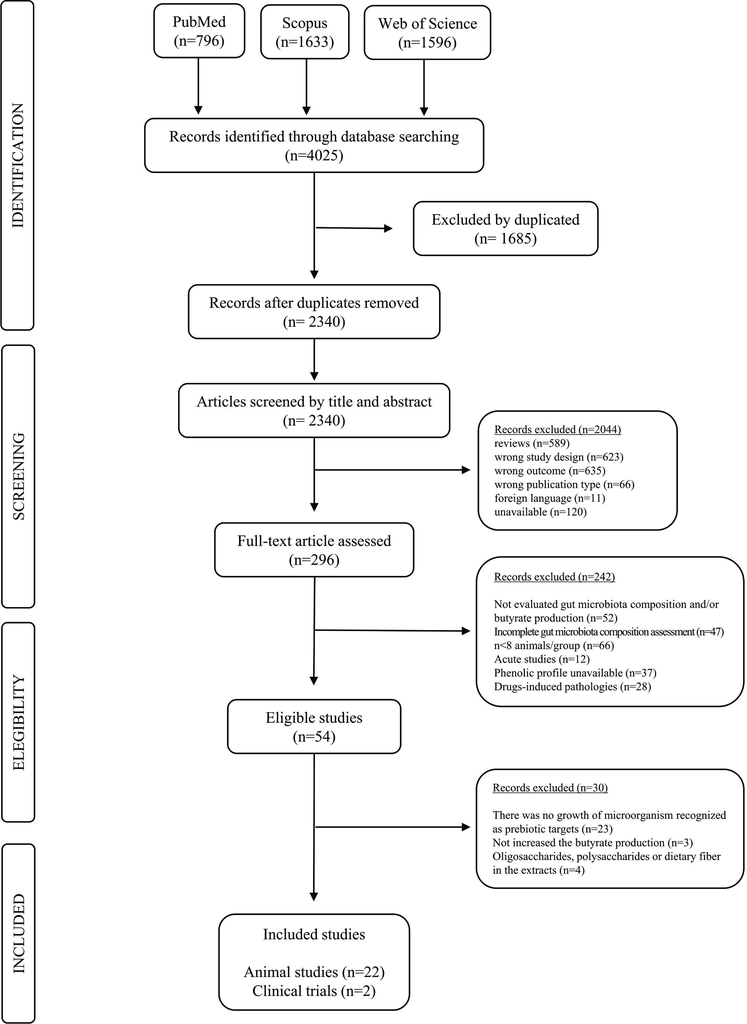

**Fig. 1.** Flowchart of the systematic review.

*A.M. Alves-Santos, et al.*

*Journal of Functional Foods 74 (2020) 104169*

3

**Table 2**

Characteristics of included studies on prebiotic effect of dietary polyphenols (n = 24).

Compound (food)

Dose

Animal/Human

Study design

Main outcome

Reference

Period (days)

Diet

Gut microbiota

Health

Animal studies

*Flavonoids*

Anthocyanins

(bilberry extract)

10, 20 or 40 mg extract/kg

bw/day (IG)

Sprague-Dawley rats

(n = 10/group)

70

STD

↑ *Lactobacillus*

↑ cecal SCFA

↓ *Firmicutes/Bacteroidetes* ratio

↓ digestive enzymes

activity

Li, Wu, et al. (2019)

Anthocyanins and proanthocyanidins

(Arctic berry extracts)

200 mg extract/kg bw/day

(water)

Male C57BL/6J mice

(n = 12/group)

56

HFHS

↑ *Akkermansia muciniphila*

(NS) cecal SCFA

↑ insulin sensitivity

Anhê et al. (2018)

Anthocyanins (grape pomace extract) and

proanthocyanidin A (cinnamon bark

extract)

grape pomace: 2 g extract/kg

diet

cinnamon bark: 8.2 g extract/

kg diet

Male C57BL/6J mice

(n = 14/group)

56

HFD

↑ *Roseburia*

(NS) cecal SCFA

↓ fat mass gain

↓ liver steatosis

Van Hul et al. (2018)

Catechins

(green tea extract)

2% of extract (diet)

Male C57BL/6J mice

(n = 10/group)

56

HFD

↑ *Bifidobacterium* and

*Akkermansia muciniphila*

↓ *Firmicutes/Bacteroidetes* ratio

↓ adiposity

Dey et al. (2019)

Catechins

(green tea polyphenols)

0.05, 0.2 or 0.8% of tea

polyphenols (diet)

HFA C57BL/6J mice

(n = 8/group)

56

HFHS

↑ fecal acetate and butyrate

↓ *Firmicutes/Bacteroidetes* ratio

↓ bw gain

↓ serum lipid profile,

glucose and insulin

Wang et al. (2018)

Catechins

(green tea polyphenols)

100, 200 or 400 mg of green

tea polyphenols/kg bw/day

(IG)

SPF C57BL/6 mice

(n = 8/group)

84

HFD

↑ *Bifidobacterium*, *Akkermansia*,

*Roseburia* (the highest dose)

↑ expression of hepatic

lipid metabolism genes

Ma et al. (2019)

Catechins and caffeine

(green tea, black tea and oolong tea water

extracts)

1% tea extract (diet)

Male C57BL/6J mice

(n = 12/group)

196

HFD

↑ fecal SCFA (oolong tea)

↓ plasma LPS

↑ glucose tolerance

↓ bw gain

Liu et al. (2019)

Catechins

(decaffeinated green and black tea

polyphenol extracts)

0.5 g extract/100 g diet

Male C57BL/6J

Mice (n = 12/group)

28

HFHS

↑ fecal propionate and butyrate

(black tea)

↓ *Firmicutes* ↑ *Bacteroidetes*

Induced bw loss

Henning et al. (2018)

Catechins

(ripened Pu-erh tea extract)

0.1, 0.2, or 0.4% of extract

(water)

Male C57BL/6N mice

(n=10/group)

56

HFD

↑ *Roseburia* and *Akkermansia*

↓ *Firmicutes/Bacteroidetes* ratio

↓ serum LPS

↓ bw gain and metabolic

endotoxemia

Lu et al. (2019)

Catechins and caffeine

(aqueous raw and ripe Pu-erh tea extracts)

0.15 or 0.4 mg extract/kg bw/

day (diet)

Male Wistar rats

(n=18/group)

77

HFHS

↑ *Akkermansia muciniphila*

↑ *Firmicutes* ↓ *Bacteroidetes*

↑ glycolysis

Xia et al. (2019)

Genistein

3 mg/kg bw/day (diet)

Male C57BL6 mice

(n=8/group)

180

HFD

↑ *Faecalibacterium*

↓ serum LPS

↓ serum triglycerides

López et al. (2018)

Hydroxysafflor yellow A

200 mg/kg bw/day (IG)

SPF C57BL/6J mice

(n=8/group)

84

HFD

↑ *Akkermansia*

↑ cecal SCFA

↓ *Firmicutes/Bacteroidetes* ratio

↓ inflammation

Liu et al. (2018)

Isoflavones (soy extract)

150 or 450 mg extract/kg bw/

day (diet)

Male Sprague Dawley rats

(n=16/group)

91

HFD

↑ *Faecalibacterium*

↑ fecal butyrate and ↓ serum LPS

↓ *Firmicutes/Bacteroidetes* ratio

↓ oxidative damage and

inflammation

Luo et al. (2019)

Naringenin

*(S. chinensis* pollen extract)

7.86 or 15.72 g extract/kg bw/

day (IG)

Male C57BL/6 mice

(n=12/group)

112

HFD

↑ *Lactobacillus*

↓ fasting blood glucose

Cheng, Chen, Liu,

Zhao, and Cao (2019)

(*continued on next page*)

*A.M. Alves-Santos, et al.*

*Journal of Functional Foods 74 (2020) 104169*

4

**Table 2** (*continued*)

Compound (food)

Dose

Animal/Human

Study design

Main outcome

Reference

Period (days)

Diet

Gut microbiota

Health

Polymeric and oligomeric procyanidin (apple)

0.5% procyanidins (diet)

C57BL/6J male mice

(n=10/group)

140

HFHS

↑ *Akkermansia* (eight times)

↓ *Firmicutes/Bacteroidetes* ratio

↓ serum LPS

Attenuate bw gain

Masumoto et al.

(2016)

Proanthocyanidin

(cranberry extract)

200 mg extract/kg bw/day

(water)

Male C57Bl/6J mice

(n=8–11/group)

147

HFHS

↑ *Akkermansia muciniphila*

↓ *Firmicutes/Bacteroidetes ratio*

↑ insulin sensitivity

Anhê et al. (2017)

Proanthocyanidin

(cranberry extract)

200 mg extract/kg bw/day

(IG)

Male C57Bl/6J mice

(n=12/group)

56

HFHS

↑ *Akkermansia* spp.

↓ plasma LPS

↓ bw gain

↑ insulin sensitivity

Anhê et al. (2015)

*Other polyphenols*

*Lignans* - syringaresinol

10 or 50 mg/kg bw/day (diet)

Male C57BL/6 mice

(n=12/group)

70

STD

↑ *Lactobacillus* and

*Bifidobacterium*

↓ serum LPS-binding protein

↑ immune system

Cho et al. (2016)

*Phenolic acids* - dicaffeoylquinic acids

(*Ilex kudingcha)*

3.3 or 10 mg/mouse (IG)

SPF male C57BL/6 mice

(n=8/group)

56

HFD

↑ *Bifidobacterium* and

*Akkermansia*

↓ serum LPS

↓ inflammation

Xie et al. (2019)

*Stilbenes* - pterostilbene

15 mg/kg bw/day (IG)

Zucker (*fa/fa*) rats

(n=10/group)

42

STD

↑ *Akkermansia muciniphila*

↓ *Firmicutes*

↑ insulin sensitivity

Etxeberria et al.

(2017)

*Stilbenes* - resveratrol

200 mg/kg bw/day (diet)

Male Kunming mice

(n=8/group)

84

HFD

↑ *Lactobacillus* and

*Bifidobacterium*

↓ *Firmicutes* ↑ *Bacteroidetes*

↓ bw

↓ blood glucose and lipid

Qiao et al. (2014)

*Other polyphenols* - vanillin

0.1% diet

Male C57BL/6J mice

(n=7–8/group)

98

HFD

↓ *Firmicutes*

↑ cecal SCFA

↑ insulin sensitivity

↓ inflammation

Guo, Han, Zhan, You,

and Huang (2018)

Clinical trials

Anthocyanins

(wild blueberry drink)

25 g/250 mL água

20 healthy male individuals

crossover, placebo

controlled

(6 weeks)

↑ *Lactobacillus acidophilus*

↑ *Bifidobacterium* spp.

NR

Vendrame et al.

(2011)

Punicalagins and ellagic acid (pomegranate

extract)

0.45 g or 1.8 g extract

(capsules)

49 overweight-obese subjects

(mild hyperlipidemia)

double-blind,

crossover, placebo

controlled

(9 weeks)

↑ *Faecalibacterium*

↓ plasma LBP

NR

González-Sarrías et al.

(2018)

bw: body weight, SCFA: short-chain fatty acids, STD: standard, chow and normal diet, HFD: high-fat diet, HFHS: high-fat/high-sucrose diet, IG: intragastric, LPS: lipopolysaccharides, HFA: human flora-associated, SPF:

specific-pathogen-free, (NS): not significant or not affected, NR: not reported, LBP: lipopolysaccharide-binding protein, ↑ and ↓: increase and decrease in the specific parameter, respectively.

*A.M. Alves-Santos, et al.*

*Journal of Functional Foods 74 (2020) 104169*

5

The intervention with soy isoflavone extract containing 51%

daidzin, 30% glycitin and 9% genistein increased the abundance of

*Faecalibacterium* and the fecal butyrate content in obese rats, and im-

proved intestinal barrier function through increasing the expressions of

zonula occludens 1 (ZO-1), occludin and mucin 2 (Muc-2) genes (Luo

et al., 2019). An increase of the *Faecalibacterium* genus was also ob-

served after the consumption of genistein (López et al., 2018).

The effects of other flavonoid subclasses were investigated in two

studies, in which the intervention samples were hydroxysafflor yellow

A (HSYA) (Liu et al., 2018) and *Schisandra chinensis* pollen extract

(Cheng et al., 2019). The HSYA supplementation, a compound with a

mono-chalcone glycoside structure, increased the abundance *of Akker-*

*mansia*, and the production of acetate, propionate, and butyrate.

Moreover, the number of goblet cells and the expression of tight junc-

tion proteins ZO-1 were increased after intragastric supplementation

with HSYA (Liu et al., 2018). Regarding the *S. chinensis* pollen extract,

the most abundant phenolic compound was naringenin (1.89 mg/g), a

flavanone. Treatment with pollen extract increased *Lactobacillus* in

obese mice with a dose-effect relationship (Cheng, Chen, Liu, et al.,

2019).

*3.2.1.2. Other*

*polyphenols*. Prebiotic

effect

of

other

phenolic

compounds, like lignans, phenolic acids, stilbenes and vanillin, was

evaluated in five animal studies (Cho et al., 2016; Etxeberria et al.,

2017; Guo et al., 2018; Qiao et al., 2014; Xie et al., 2019). In summary,

there was an increase in the abundance of *Lactobacillus*, *Bifidobacterium*

and *Akkermansia*, and a reduction in serum concentrations of pro-

inflammatory cytokines and expression of lipid synthesis related genes.

The consumption of syringaresinol, a lignan present in oilseeds,

cereal brans and berry seeds, enhanced the population of *Lactobacillus*

and *Bifidobacterium*, and reduced serum lipopolysaccharide-binding

protein (LBP) concentration (Cho et al., 2016). Supplementation with

aqueous kudingcha extract, composed by 3,4-di-*O*-caffeoylquinic acids

(3,4-diCQAs − 26.9%), 3,5-diCQAs (42.3%) and 4,5-diCQAs (30.8%),

increased the abundance of *Bifidobacterium* and *Akkermansia*, and de-

creased the concentrations of serum interleukin 6 (IL-6), tumor necrosis

factor-alpha (TNF-α) and lipopolysaccharides (LPS) and the hepatic

expression of lipid synthesis related genes (Xie et al., 2019). The sup-

plementation with resveratrol, the largest representative of the stil-

benes class, increased the abundance of *Lactobacillus* and *Bifido-*

*bacterium*, and decreased the genes expression related to fatty acids

synthesis, adipogenesis and lipogenesis in mice fed a high-fat diet (Qiao

et al., 2014). Animals treated with a standard diet supplemented with

pterostilbene, a dimethoxy resveratrol derivative, showed an increase

in the abundance of *Akkermansia muciniphila*, and an improvement in

insulin sensitivity (Etxeberria et al., 2017). An increase in the produc-

tion of acetate, propionate and butyrate and a decrease in the high

concentrations of inflammatory factors (LPS, IL-6, and TNF-α) were

observed in mice fed a high-fat diet after the supplementation with

vanillin (Guo, Han, et al., 2018).

*3.2.2. Clinical trials*

The effect of anthocyanins was also evaluated in a crossover clinical

trial, in which the consumption of a wild blueberry drink (375 mg of

anthocyanins) by healthy adults increased *Bifidobacterium* spp. and

*Lactobacillus acidophilus* (Vendrame et al., 2011). In another clinical

trial with overweight-obese individuals, the consumption of pome-

granate extract (1.8 g/day, 656 mg of phenolics) rich in hydro-

xybenzoic acids (punicalagins and free ellagic acid) increased *Faecali-*

*bacterium* and decreased the concentration of plasma LBP (González-

Sarrías et al., 2018).

*3.3. Methodological quality assessment of studies*

The animal studies were generally classified as low or unclear re-

garding the risk of bias (Table S1). None of the included studies

satisfied all areas established by the SYRCLE’s tool for methodological

quality assessment of animal studies. Data on selection bias (baseline

characteristics and allocation concealment), performance bias (random

housing and blinding), and detection bias (random outcome assessment

and blinding) were unavailable in all studies. The clinical trials

(González-Sarrías et al., 2018; Vendrame et al., 2011), evaluated by

Cochrane Collaboration's tool, were at low-risk for selection bias

(random sequence generation), performance bias (blinding of partici-

pants and personnel), reporting bias (selective reporting), and other

bias. In addition, these studies were unclear for selection bias (alloca-

tion concealment) and detection bias (blinding of outcome assessment)

and showed high-risk for attrition bias (incomplete outcome data).

**4. Discussion**

To our knowledge, this is the first systematic review aiming to ex-

plore the prebiotic effect of dietary polyphenols investigated in pre-

clinical and clinical studies. We found 24 studies of which: 8 showed an

increased abundance of *Lactobacillus* spp. and/or *Bifidobacterium* spp.

(Cheng, Chen, Liu, et al., 2019; Cho et al., 2016; Dey et al., 2019; Li,

Wu, et al., 2019; Ma et al., 2019; Qiao et al., 2014; Vendrame et al.,

*mansia* spp. (Anhê et al., 2015, 2017; Dey et al., 2019; Etxeberria et al.,

2017; Liu et al., 2018; Lu et al., 2019; Ma et al., 2019; Masumoto et al.,

2016; Xia et al., 2019; Xie et al., 2019); 3 showed an increased abun-

dance of *Faecalibacterium* spp. (González-Sarrías et al., 2018; López

et al., 2018; Luo et al., 2019); and 3 showed an increased abundance of

*Roseburia* spp. (Lu et al., 2019; Ma et al., 2019; Van Hul et al., 2018).

Seven studies reported an increase in the production of SCFA, including

butyrate (Guo, Han, et al., 2018; Henning et al., 2018; Li, Wu, et al.,

2019; Liu et al., 2018, 2019; Luo et al., 2019; Wang et al., 2018).

The current definition of prebiotic recognizes that prebiotic targets

extend beyond the stimulation of *Bifidobacterium* and *Lactobacillus*, and

include other microorganisms such as *Roseburia*, *Eubacterium* and

*Faecalibacterium* spp., but are not limited to these (Gibson et al., 2017).

Thereby, the inclusion criteria applied in this systematic review is in

accordance with the current concept of prebiotics. The health benefits

associated with prebiotics are immune modulation, increased mineral

absorption, improved bowel function, and a positive effect on glucose

homeostasis, inflammation, blood lipid profile, satiety and defense

against pathogens (Sanders et al., 2019). Although these effects cannot

be easily extrapolated to the human gut microbiota, many of them seem

to be mediated by SCFA, especially acetate, propionate, and butyrate.

The pathway that explains how polyphenols increase the production

of SCFA is not yet fully understood. It is believed that the increase of

anaerobic microorganisms, such as *Lactobacillus*, *Lachnospiraceae* and

*Ruminococcaceae* can promote the increase of SCFA, especially of bu-

tyrate (Li, Wu, et al., 2019; Liu et al., 2018, 2019). Another possible

explanation is associated with decafeinated green tea and black tea

polyphenols that have been shown to inhibit α-amylase and α-gluco-

sidase in saliva and small intestine, which may lead to residual carbo-

hydrate in the large intestine providing substrate for the SCFA pro-

duction (Henning et al., 2018). It is worth mentioning that SCFA are the

major mediators among nutrition, gut microbiota, physiology, and pa-

thology (Ríos-Covián et al., 2016). The butyrate has been investigated

most extensively, and it is recognized that butyrate-producing bacteria

and butyrate per se may be beneficial for human health (Koh, De

Vadder, Kovatcheva-Datchary, & Bäckhed, 2016), suggesting it as a

biomarker of prebiotic effect.

The studies reviewed here reported that the health benefits asso-

ciated with the consumption of catechins were reduced concentrations

of serum low-density lipoprotein cholesterol (LDL-c) (Ma et al., 2019),

glucose and insulin (Wang et al., 2018). Studies also found that ca-

techins could prevent an increase in toll-like receptor 4 (TLR4)/ nuclear

factor kappa B (NFκB)-dependent inflammatory genes (Dey et al.,

2019), and increase the hepatic adenosine monophosphate-activated

*A.M. Alves-Santos, et al.*

*Journal of Functional Foods 74 (2020) 104169*

6

protein kinase (AMPK) phosphorylation (Henning et al., 2018). Besides,

the consumption of green tea extract containing 48% epigallocatechin

gallate prevented from a decrease in the expression of intestinal tight

junction proteins induced by a high-fat diet (Dey et al., 2019). The

treatment with soy isoflavone and HSYA improved intestinal barrier

function through increasing the number of goblet cells and the ex-

pression of tight junction proteins ZO-1, occludin and Muc-2 (Liu et al.,

2018; Luo et al., 2019). Digestive enzymes activities (β-glucosidase, β-

2019). The health effects of proanthocyanidins consumption were im-

proved glucose tolerance and insulin sensitivity, upregulation of lipid

catabolism genes (PPARα), and downregulation of pro-inflammatory

genes (COX2, TNFα) in the liver (Anhê et al., 2015, 2017; Masumoto

et al., 2016).

Dietary flavonoids are consumed predominantly as glycosides

(conjugated to sugar), which hinders the absorption of these com-

pounds by the small intestine (Kawabata, Yoshioka, & Terao, 2019).

Glycosylated flavonoids can serve as the sole source of carbon and

energy for some microorganisms in the gut microbiota, which pre-

ferentially ferment the sugars linked to flavonoids. Thus, it could ex-

plain the prebiotic effect observed for these compounds (Braune &

Blaut, 2016). For instance, aqueous extract of jaboticaba, a Brazilian

native fruit rich in cyanidin-3-O-glucoside and delphinidin-3-O-gluco-

side, modulated the abundance of *Lactobacillus* and *Bifidobacterium* in

rats with induced-colitis (Silva-Maia et al., 2019). Cyanidin-3-O-glu-

coside ameliorated gut microbial dysbiosis caused by 3-chloro-1,2-

propanediol (chemical food contaminant) in rats (Chen et al., 2019). In

other study, the Quzhou Fructus Aurantii extract, rich in naringin, a

natural flavanone glycoside, increased the genus *Akkermansia* and the

expression of tight junction proteins, and reduced metabolic en-

dotoxemia in mice fed high-fat diet (Bai et al., 2019).

Most dietary polyphenols arrive intact in the colon, where they

become substrates for the gut microbiota, producing better-absorbing

metabolites (Mojzer et al., 2016; Kawabata et al., 2019). The flavo-

noids, such as epicatechin, catechin, procyanidin and quercetin, when

metabolized by gut microbiota, generate hydroxy phenylacetic and

hydroxyphenyl propionic acids (Shortt et al., 2018). Equol and O-des-

methylangolensin (ODMA) are active metabolites produced by the ac-

tion of colonic bacteria on soy isoflavones (Mayo, Vázquez, & Flórez,

2019). The urolithins, in turn, are metabolites produced from ellagi-

tannins and ellagic acid by the human gut microbiota (Tomás-Barberán

et al., 2017). These metabolites also have beneficial health effects, such

as estrogenic and antioxidant activity (Mayo et al., 2019), anti-in-

flammatory and antioxidant effects (Lee, Park, Lee, Ahn, & Kim, 2019),

and hepatoprotective effect (Zhao et al., 2018). Thus, further studies

are warranted to investigate the potential of these metabolites as pre-

biotic effect markers, such as the SCFA modulation.

Studies with syringaresinol in male C57BL/6 mice (Cho et al., 2016)

and pomegranate extract in overweight-obese individuals (González-

Sarrías et al., 2018) demonstrated a decrease in serum LBP, indicating

that polyphenols could modulate metabolic endotoxemia (Fuke,

Nagata, Suganuma, & Ota, 2019). LBP is a glycoprotein mainly syn-

thesized in the hepatocytes with long half-life in the blood and can bind

to LPS promoting an LPS-induced immune response via toll-like re-

ceptors in macrophages (Jamar, Ribeiro, & Pisani, 2020). LPS, known as

endotoxin, is a breakdown product present in the outer membrane of

gram-negative bacteria, composed by an O-antigen portion in its outer

part and by a lipid-A portion in its inner part. The lipid-A portion exerts

most of the immunogenic effects, such as the activation of TLR4,

through the formation of the complex containing LBP and the CD14 co-

receptor, which signals the NFκB activation to upregulate pro-in-

flammatory mediators causing low-grade inflammation. The O-antigen

portion activates components of the adaptive immunity, intending to

induce the production of antibodies. Therefore, plasma LBP may be an

inflammation marker caused by endotoxins (Jamar et al., 2020).

The dysbiosis of the gut microbiota caused by a high-fat diet has

been considered as a possible cause for metabolic endotoxemia (Fuke

et al., 2019). Thus, it is expected that the consumption of polyphenols

may also improve the metabolic endotoxemia associated to dysbiosis,

since the consumption of catechins (Liu et al., 2019; Lu et al., 2019),

isoflavones (López et al., 2018; Luo et al., 2019), proanthocyanidins

(Anhê et al., 2015; Masumoto et al., 2016), and dicaffeoylquinic acids

(Xie et al., 2019) decreased plasma or serum LPS in animals fed a high-

fat diet. Circulating LPS is released by lysis of a fraction of the bacterial

cell wall and flows into the blood by increasing intestinal permeability.

The excess intestinal LPS itself, caused by dysbiosis, destroys the

narrow junction of intestinal epithelial cells via TLR4 and inhibits

mRNA expression of factors related to the restricted junction, such as

ZO-1 and occludin, in the intestinal epithelial cell. Therefore, LPS is

considered an inflammation marker for dysbiosis (Fuke et al., 2019).

The improvement of the intestinal barrier function through in-

creasing the expressions of ZO-1, occludin and Muc-2 genes, and of the

mucin-producing goblet cells number is one of the possible mechanisms

associated with the prebiotic effects of catechins (Dey et al., 2019), soy

factor 4 (KLF4), a marker of goblet cells, and Muc2 mRNA expression in

the proximal colon were also associated with the administration of

proanthocyanidins rich-cranberry extract, supporting that these poly-

phenols could be able to stimulate mucus production (Fig. 2), and

therefore create an ecological niche for the *Akkermansia* spp., a mucus-

degrading bacterium (Anhê et al., 2015). Xia et al. (2019) reported an

increased abundance of *Akkermansia* spp. through an increase in other

markers, such as type II and III secretion system proteins, the elongation

factor thermo unstable, and a glyceraldehyde-3-phosphate dehy-

drogenase. This methodology was not observed in other studies. In this

review, *Akkermansia* spp. was included as prebiotic target along with

the bacteria recognized as probiotics by the Consensus Statement on the

Definition and Scope of Prebiotics (Gibson et al., 2017), considering the

recent evidences in literature about the relationship among *Akker-*

*mansia* spp., gut microbiota and human health (Cani & de Vos, 2017;

Jayachandran, Chung, & Xu, 2019; Sanders et al., 2019). *Akkermansia*

spp. and *Propionibacterium* spp. are promising candidates among the

next generation of microorganisms to be recognized as prebiotic targets

(Sanders et al., 2019).

There is also evidence of an additional mechanism by which poly-

phenols protect the intestinal barrier against oxidative stress. A decrease in

(100 mg/kg body weight/day). The improvement of intestinal oxidative

stress is supposed to be a potential mechanism for the modulation of tea

polyphenols in the gut microbiota (Ma et al., 2019), since excess reactive

oxygen species will damage the cell membrane and disrupt the tight

junctions leading to an increased intestinal permeability and the develop-

ment of metabolic disorders (Qiao, Sun, Ding, Le, & Shi, 2013). The tight

junctions are multiprotein complexes that maintain barrier function be-

tween the enterocytes, creating paracellular barrier properties, which are

composed by transmembrane proteins which control the transport across

the intercellular space between adjacent cells and cytoplasmic plaque

(Costea et al., 2019). The main components of the cytoplasmic plaque are

claudin and zonula occludens proteins. In oxidative stress, the interactions

of occludin with claudins or proteins of the zonula family are affected di-

rectly influencing the formation and function of the tight junctions. Oxi-

dative stress downregulates occludin, reduces its specific membrane loca-

lization and regulatory contribution to barrier tightness via multiple

signaling pathways (Costea et al., 2019). Nonetheless, most of the evidence

is based *in vitro* and animal studies, and then further studies in humans are

needed to clarify these mechanisms.

Regarding the methodological quality of the included papers, none

of the studies satisfied all criteria established by the SYRCLE and

Cochrane Collaboration's tool. No preclinical studies provide detailed

descriptions of the methods used for allocation concealment, random

*A.M. Alves-Santos, et al.*

*Journal of Functional Foods 74 (2020) 104169*

7

housing and random outcome assessment, or blinding researchers and

outcome assessors. The clinical trials did not provide details on allo-

cation concealment and blinding of outcome assessment. The absence

of descriptions regarding sample losses in the preclinical and clinical

studies also was noted. Therefore, we suggest the use of these tools in

experimental planning, as a reference for well-designed studies aiming

to reduce the risk of bias and allow more consistent conclusions.

It is noteworthy that the included studies had quite heterogeneous

designs, including differences in the intervention period, the metho-

dology for gut microbiome analysis, and the supplementation with

polyphenol (food sample and dosage), as well as the polyphenols profile

of the samples. Additional studies with isolated polyphenols are needed

to eliminate the effects of other compounds in the extract, especially in

clinical trials. Moreover, we suggest that further studies aiming to

evaluate the prebiotic effect of dietary polyphenols should be carried

out according to the internationally accepted prebiotics definition, with

complete assessment of the gut microbiota, including the microorgan-

ism’s genera. The low number of studies on humans is also a limitation

in this systematic review.

**5. Conclusion**

The prebiotic effect of dietary polyphenols, especially catechins,

anthocyanins, and proanthocyanidins, has strong evidence based on

preclinical studies. Despite the limitations of these studies, it is evident

that polyphenols can stimulate the growth of microorganisms re-

cognized as prebiotic targets (*Lactobacillus* spp., *Bifidobacterium* spp.,

*Akkermansia* spp., *Roseburia* spp., and *Faecalibacterium* spp.), and in-

crease the production of SCFA, including butyrate. Nevertheless, well-

designed clinical trials are warranted to prove the prebiotic effect of

polyphenols on humans.

**Ethics statement**

This research did not include any human subjects and animal ex-

periments.

**CRediT authorship contribution statement**

**Aline Medeiros Alves-Santos:** Conceptualization, Data curation,

Formal analysis, Investigation, Methodology, Software, Writing - ori-

ginal draft, Writing - review & editing. **Clara Sandra Araújo Sugizaki:**

Conceptualization, Data curation, Formal analysis, Investigation,

Methodology, Software, Writing - original draft, Writing - review &

editing. **Glaucia Carielo Lima:** Conceptualization, Data curation,

Supervision, Visualization, Writing - review & editing. **Maria**

**Margareth**

**Veloso**

**Naves:**

Conceptualization,

Data

curation,

Supervision, Visualization, Writing - review & editing.

**Declaration of Competing Interest**

The authors declare that they have no known competing financial

interests or personal relationships that could have appeared to influ-

ence the work reported in this paper.

**Acknowledgments**

The authors thank the CAPES (Coordenação de Aperfeiçoamento de

Pessoal de Nível Superior, Brazil) for a research scholarship.

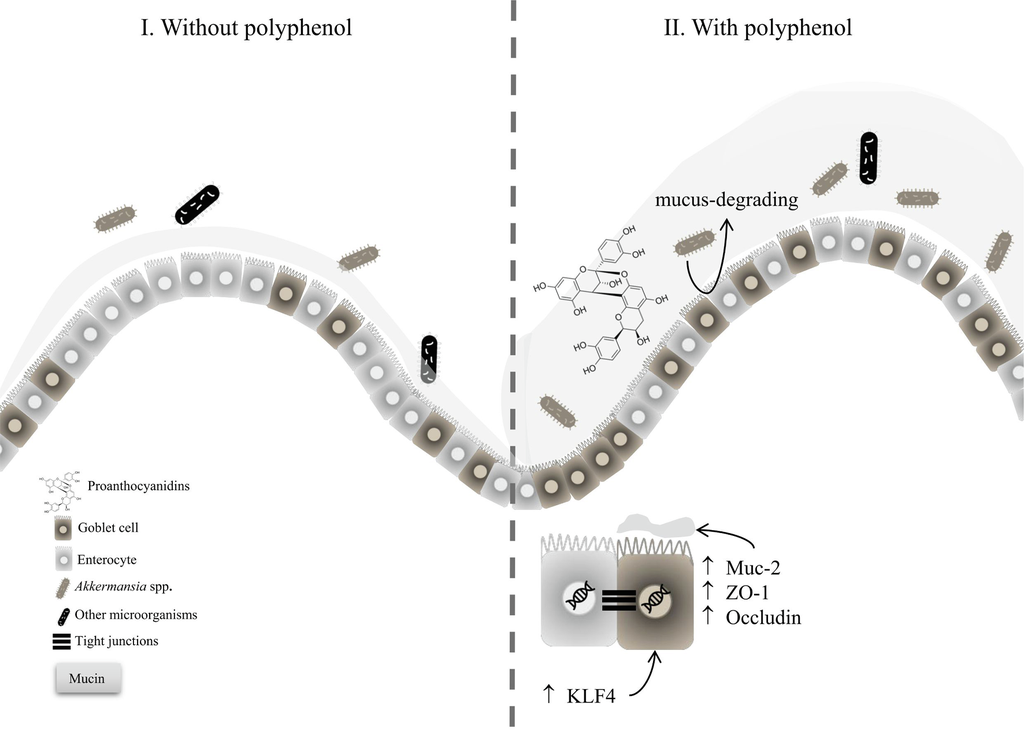

**Fig. 2.** Mechanism of mucin synthesis modulation by proanthocyanidins in the hindgut. KLF4: kruppel-like factor 4, Muc-2: mucin 2, ZO-1: zonula occludens 1. The

consumption of polyphenols, represented in the figure by proanthocyanidins, may increase the number of goblet cells, according to the Kruppel-like factor 4 (KLF4)

marker, and consequently, the mucin production; so the enhanced mucin provides a favorable environment for the proliferation of *Akkermansia* spp., a mucus-

degrading bacterium (Anhê et al., 2015; Xia et al., 2019). In addition, increased expression of ZO-1 and occludin can be observed after the consumption of

polyphenols, decreasing the intestinal permeability through the junction of epithelial cells (tight junctions) (Dey et al., 2019; Luo et al., 2019; Liu et al., 2019).

*A.M. Alves-Santos, et al.*

*Journal of Functional Foods 74 (2020) 104169*

8

**Funding**

This research did not receive any specific grant from funding

agencies in the public, commercial, or not-for-profit sectors.

**Appendix A. Supplementary data**

Supplementary data to this article can be found online at https://

doi.org/10.1016/j.jff.2020.104169.

**References**

Anhê, F. F., Nachbar, R. T., Varin, T. V., Vilela, V., Dudonné, S., Pilon, G., ... Marette, A.

(2017). A polyphenol-rich cranberry extract reverses insulin resistance and hepatic

steatosis independently of body weight loss. *Molecular Metabolism, 6*(12), 1563–1573.

https://doi.org/10.1016/j.molmet.2017.10.003.

Anhê, F. F., Roy, D., Pilon, G., Dudonné, S., Matamoros, S., Varin, T. V., ... Marette, A.

(2015). A polyphenol-rich cranberry extract protects from diet-induced obesity, in-

sulin resistance and intestinal inflammation in association with increased

*Akkermansia* spp. population in the gut microbiota of mice. *Gut, 64*(6), 872–883.

https://doi.org/10.1136/gutjnl-2014-307142.

Anhê, F. F., Varin, T. V., Le Barz, M., Pilon, G., Dudonné, S., Trottier, J., ... Marette, A.

(2018). Arctic berry extracts target the gut–liver axis to alleviate metabolic en-

dotoxaemia, insulin resistance and hepatic steatosis in diet-induced obese mice.

*Diabetologia, 61*(4), 919–931. https://doi.org/10.1007/s00125-017-4520-z.

Bai, Y., Wang, S., Wang, X., Weng, Y., Fan, X., Sheng, H., ... Zhang, F. (2019). The fla-

vonoid-rich Quzhou Fructus Aurantii extract modulates gut microbiota and prevents

obesity in high-fat diet-fed mice. *Nutrition and Diabetes, 9*(1), 1–11. https://doi.org/

10.1038/s41387-019-0097-6.

Bian, Y., Wei, J., Zhao, C., & Li, G. (2020). Natural polyphenols targeting senescence: A

novel prevention and therapy strategy for cancer. *International Journal of Molecular*

*Sciences, 21*(2), 1–17. https://doi.org/10.3390/ijms21020684.

Braune, A., & Blaut, M. (2016). Bacterial species involved in the conversion of dietary

flavonoids in the human gut. *Gut Microbes, 7*(3), 216–234. https://doi.org/10.1080/

19490976.2016.1158395.

Cani, P. D., & de Vos, W. M. (2017). Next-generation beneficial microbes: The case of

*Akkermansia muciniphila*. *Frontiers in Microbiology, 8*, 1–8. https://doi.org/10.3389/

fmicb.2017.01765.

Casanova-Marti, A., Serrano, J., Portune, K. J., Sanz, Y., Blay, M. T., Terra, X., ... Pinent,

M. (2018). Grape seed proanthocyanidins influence gut microbiota and en-

teroendocrine secretions in female rats. *Food and Function, 9*(3), 1672–1682. https://

doi.org/10.1039/c7fo02028g.

Chai, S. C., Davis, K., Zhang, Z., Zha, L., & Kirschner, K. F. (2019). Effects of tart cherry

juice on biomarkers of inflammation and oxidative stress in older adults. *Nutrients,*

*11*(2), 1–10. https://doi.org/10.3390/nu11020228.

Chen, G., Wang, G., Zhu, C., Jiang, X., Sun, J., Tian, L., & Bai, W. (2019). Effects of

cyanidin-3-O-glucoside on 3-chloro-1,2-propanediol induced intestinal microbiota

dysbiosis in rats. *Food and Chemical Toxicology, 133*, 110767. https://doi.org/10.

1016/j.fct.2019.110767.

Cheng, L., Chen, Y., Zhang, X., Zheng, X., Cao, J., Wu, Z., ... Cheng, K. (2019). A meta-

genomic analysis of the modulatory effect of *Cyclocarya paliurus* flavonoids on the

intestinal microbiome in a high-fat diet-induced obesity mouse model. *Journal of the*

*Science of Food and Agriculture, 99*(8), 3967–3975. https://doi.org/10.1002/jsfa.

9622.

Cheng, N., Chen, S., Liu, X., Zhao, H., & Cao, W. (2019). Impact of SchisandraChinensis

bee pollen on nonalcoholic fatty liver disease and gut microbiota in highfat diet in-

duced obese mice. *Nutrients, 11*(2), 1–16. https://doi.org/10.3390/nu11020346.

Chiu, H. F., Chen, Y. J., Lu, Y. Y., Han, Y. C., Shen, Y. C., Venkatakrishnan, K., & Wang, C.

K. (2017). Regulatory efficacy of fermented plant extract on the intestinal microflora

and lipid profile in mildly hypercholesterolemic individuals. *Journal of Food and Drug*

*Analysis, 25*(4), 819–827. https://doi.org/10.1016/j.jfda.2016.10.008.

Cho, S. Y., Kim, J., Lee, J. H., Sim, J. H., Cho, D. H., Bae, I. H., ... Kim, H. R. (2016).

Modulation of gut microbiota and delayed immunosenescence as a result of syr-

ingaresinol consumption in middle-aged mice. *Scientific Reports, 6*, 1–14. https://doi.

org/10.1038/srep39026.

Cires, M. J., Navarrete, P., Pastene, E., Carrasco-Pozo, C., Valenzuela, R., Medina, D. A., ...

Gotteland, M. (2019). Effect of a proanthocyanidin-rich polyphenol extract from

avocado on the production of amino acid-derived bacterial metabolites and the mi-

crobiota composition in rats fed a high-protein diet. *Food and Function, 10*(7),

4022–4035. https://doi.org/10.1039/c9fo00700h.

Collins, B., Hoffman, J., Martinez, K., Grace, M., Lila, M. A., Cockrell, C., ... McIntosh, M.

(2016). A polyphenol-rich fraction obtained from table grapes decreases adiposity,

insulin resistance and markers of inflammation and impacts gut microbiota in high-

fat-fed mice. *Journal of Nutritional Biochemistry, 31*, 150–165. https://doi.org/10.

1016/j.jnutbio.2015.12.021.

Costea, L., Mészáros, A., Bauer, H., Bauer, H. C., Traweger, A., Wilhelm, I., ... Krizbai, I. A.

(2019). The blood–brain barrier and its intercellular junctions in age-related brain

disorders. *International Journal of Molecular Sciences, 20*(21), 1–28. https://doi.org/

10.3390/ijms20215472.

Cowan, T. E., Palmnäs, M. S. A., Yang, J., Bomhof, M. R., Ardell, K. L., Reimer, R. A., ...

Shearer, J. (2014). Chronic coffee consumption in the diet-induced obese rat: Impact

on gut microbiota and serum metabolomics. *Journal of Nutritional Biochemistry, 25*(4),

489–495. https://doi.org/10.1016/j.jnutbio.2013.12.009.

Cueva, C., Silva, M., Pinillos, I., Bartolomé, B., & Moreno-Arribas, M. V. (2020). Interplay

between dietary polyphenols and oral and gut microbiota in the development of

colorectal cancer. *Nutrients, 12*(3), 1–19. https://doi.org/10.3390/nu12030625.

Dey, P., Sasaki, G. Y., Wei, P., Li, J., Wang, L., Zhu, J., ... Bruno, R. S. (2019). Green tea

extract prevents obesity in male mice by alleviating gut dysbiosis in association with

improved intestinal barrier function that limits endotoxin translocation and adipose

inflammation. *Journal of Nutritional Biochemistry, 67*, 78–89. https://doi.org/10.

1016/j.jnutbio.2019.01.017.

Etxeberria, U., Hijona, E., Aguirre, L., Milagro, F. I., Bujanda, L., Rimando, A. M., ...

Portillo, M. P. (2017). Pterostilbene-induced changes in gut microbiota composition

in relation to obesity. *Molecular Nutrition and Food Research, 61*(1), 1–12. https://doi.

org/10.1002/mnfr.201500906.

Fang, C., Kim, H., Yanagisawa, L., Bennett, W., Sirven, M. A., Alaniz, R. C., ... Mertens-

Talcott, S. U. (2019). Gallotannins and *Lactobacillus plantarum* WCFS1 mitigate high-

fat diet-induced inflammation and induce biomarkers for thermogenesis in adipose

tissue in gnotobiotic mice. *Molecular Nutrition and Food Research, 63*(9), 1–12.

https://doi.org/10.1002/mnfr.201800937.

Fuke, N., Nagata, N., Suganuma, H., & Ota, T. (2019). Regulation of gut microbiota and

metabolic endotoxemia with dietary factors. *Nutrients, 11*(10), 1–38. https://doi.org/

10.3390/nu11102277.

Gao, X., Xie, Q., Kong, P., Liu, L., Sun, S., Xiong, B., ... Xiang, H. (2018). Polyphenol- and

caffeine-rich postfermented Pu-erh tea improves dietinduced metabolic syndrome by

remodeling intestinal homeostasis in mice. *Infection and Immunity, 86*(1), 1–16.

https://doi.org/10.1128/IAI.00601-17.

Garcia-Mazcorro, J. F., Pedreschi, R., Chew, B., Dowd, S. E., Kawas, J. R., & Noratto, G.

(2018). Dietary supplementation with raspberry extracts modifies the fecal micro-

biota in obese diabetic db/db mices. *Journal of Microbiology and Biotechnology, 28*(8),

1247–1259. https://doi.org/10.4014/jmb.1803.03020.

Gibson, G. R., Hutkins, R., Sanders, M. E., Prescott, S. L., Reimer, R. A., Salminen, S. J., ...

Reid, G. (2017). Expert consensus document: The International Scientific Association

for Probiotics and Prebiotics (ISAPP) consensus statement on the definition and scope

of prebiotics. *Nature Reviews Gastroenterology and Hepatology, 14*(8), 491–502.

https://doi.org/10.1038/nrgastro.2017.75.

Ginés, I., Gil-Cardoso, K., Terra, X., Blay, M., Pérez-Vendrell, A. M., Pinent, M., & Ardévol,

A. (2019). Grape seed proanthocyanidins target the enteroendocrine system in ca-

feteria-diet-fed rats. *Molecular Nutrition and Food Research, 63*(11), 1–7. https://doi.

org/10.1002/mnfr.201800912.

González-Sarrías, A., García-Villalba, R., Romo-Vaquero, M., Alasalvar, C., Örem, A.,

Zafrilla, P., ... Espín, J. C. (2017). Clustering according to urolithin metabotype ex-

plains the interindividual variability in the improvement of cardiovascular risk bio-

markers in overweight-obese individuals consuming pomegranate: A randomized

clinical trial. *Molecular Nutrition and Food Research, 61*(5), 1–14. https://doi.org/10.

1002/mnfr.201600830.

González-Sarrías, A., Romo-Vaquero, M., García-Villalba, R., Cortés-Martín, A., Selma, M.

V., & Espín, J. C. (2018). The endotoxemia marker lipopolysaccharide-binding pro-

tein is reduced in overweight-obese subjects consuming pomegranate extract by

modulating the gut microbiota: A randomized clinical trial. *Molecular Nutrition and*

*Food Research, 62*(11), 1–10. https://doi.org/10.1002/mnfr.201800160.

Griffin, L. E., Witrick, K. A., Klotz, C., Dorenkott, M. R., Goodrich, K. M., Fundaro, G., …

Neilson, A. P. (2017). Alterations to metabolically active bacteria in the mucosa of

the small intestine predict anti-obesity and anti-diabetic activities of grape seed ex-

tract in mice. Food and Function, 8(10), 3510–3522. 10.1039/c7fo01236e.

Grzelak-Błaszczyk, K., Milala, J., Kosmala, M., Kołodziejczyk, K., Sójka, M., Czarnecki, A.,

... Jurgoński, A. (2018). Onion quercetin monoglycosides alter microbial activity and

increase antioxidant capacity. *Journal of Nutritional Biochemistry, 56*, 81–88. https://

doi.org/10.1016/j.jnutbio.2018.02.002.

Guo, J., Han, X., Zhan, J., You, Y., & Huang, W. (2018). Vanillin alleviates high fat diet-

induced obesity and improves the gut microbiota composition. *Frontiers in*

*Microbiology, 9*, 1–12. https://doi.org/10.3389/fmicb.2018.02733.

Guo, X., Tang, R., Yang, S., Lu, Y., Luo, J., & Liu, Z. (2018). Rutin and its combination

with inulin attenuate gut dysbiosis, the inflammatory status and endoplasmic re-

ticulum stress in Paneth cells of obese mice induced by high-fat diet. *Frontiers in*

*Microbiology, 9*, 1–11. https://doi.org/10.3389/fmicb.2018.02651.

Henning, S. M., Yang, J., Hsu, M., Lee, R. P., Grojean, E. M., Ly, A., ... Li, Z. (2018).

Decaffeinated green and black tea polyphenols decrease weight gain and alter mi-

crobiome populations and function in diet-induced obese mice. *European Journal of*

*Nutrition, 57*(8), 2759–2769. https://doi.org/10.1007/s00394-017-1542-8.

Higgins, J. P. T., Altman, D. G., Gøtzsche, P. C., Jüni, P., Moher, D., Oxman, A. D., ...

Sterne, J. A. C. (2011). The Cochrane Collaboration’s tool for assessing risk of bias in

randomised trials. *BMJ, 343*(7829), 1–9. https://doi.org/10.1136/bmj.d5928.

Hooijmans, C. R., Rovers, M. M., De Vries, R. B. M., Leenaars, M., Ritskes-Hoitinga, M., &

Langendam, M. W. (2014). SYRCLE’s risk of bias tool for animal studies. *BMC Medical*

*Research Methodology, 14*(1), 1–9. https://doi.org/10.1186/1471-2288-14-43.

Jamar, G., Ribeiro, D. A., & Pisani, L. P. (2020). High-fat or high-sugar diets as trigger

inflammation in the microbiota-gut-brain axis. *Critical Reviews in Food Science and*

*Nutrition, 1–19*. https://doi.org/10.1080/10408398.2020.1747046.

Jayachandran, M., Chung, S. S. M., & Xu, B. (2019). A critical review of the relationship

between dietary components, the gut microbe *Akkermansia muciniphila*, and human

health. *Critical Reviews in Food Science and Nutrition, 1–12*. https://doi.org/10.1080/

10408398.2019.1632789.

Kawabata, K., Yoshioka, Y., & Terao, J. (2019). Role of intestinal microbiota in the

bioavailability and physiological functions of dietary polyphenols. *Molecules, 24*(2),

1–25. https://doi.org/10.3390/molecules24020370.

Koh, A., De Vadder, F., Kovatcheva-Datchary, P., & Bäckhed, F. (2016). From dietary fiber

to host physiology: Short-chain fatty acids as key bacterial metabolites. *Cell, 165*(6),

*A.M. Alves-Santos, et al.*

*Journal of Functional Foods 74 (2020) 104169*

9

1332–1345. https://doi.org/10.1016/j.cell.2016.05.041.

Lee, G., Park, J. S., Lee, E. J., Ahn, J. H., & Kim, H. S. (2019). Anti-inflammatory and

antioxidant mechanisms of urolithin B in activated microglia. *Phytomedicine, 55*,

50–57. https://doi.org/10.1016/j.phymed.2018.06.032.

Li, J., Wu, T., Li, N., Wang, X., Chen, G., & Lyu, X. (2019). Bilberry anthocyanin extract

promotes intestinal barrier function and inhibits digestive enzyme activity by reg-

ulating the gut microbiota in aging rats. *Food and Function, 10*(1), 333–343. https://

doi.org/10.1039/c8fo01962b.

Li, Q., Liu, F., Liu, J., Liao, S., & Zou, Y. (2019). Mulberry leaf polyphenols and fiber

induce synergistic antiobesity and display a modulation effect on gut microbiota and

metabolites. *Nutrients, 11*(5), 1–19. https://doi.org/10.3390/nu11051017.

Liu, J., Hao, W., He, Z., Kwek, E., Zhao, Y., Zhu, H., ... Chen, Z. Y. (2019). Beneficial

effects of tea water extracts on the body weight and gut microbiota in C57BL/6J mice

fed with a high-fat diet. *Food and Function, 10*(5), 2847–2860. https://doi.org/10.

1039/c8fo02051e.

Liu, J., Yue, S., Yang, Z., Feng, W., Meng, X., Wang, A., ... Yan, D. (2018). Oral hydro-

xysafflor yellow A reduces obesity in mice by modulating the gut microbiota and

serum metabolism. *Pharmacological Research, 134*, 40–50. https://doi.org/10.1016/j.

phrs.2018.05.012.

López, P., Sánchez, M., Perez-Cruz, C., Velázquez-Villegas, L. A., Syeda, T., Aguilar-López,

M., ... Tovar, A. R. (2018). Long-term genistein consumption modifies gut microbiota,

improving glucose metabolism, metabolic endotoxemia, and cognitive function in

mice fed a high-fat diet. *Molecular Nutrition and Food Research, 62*(16), 1–12. https://

doi.org/10.1002/mnfr.201800313.

Lu, X., Liu, J., Zhang, N., Fu, Y., Zhang, Z., Li, Y., ... Cao, Y. (2019). Ripened Pu-erh tea

extract protects mice from obesity by modulating gut microbiota composition.

*Journal of Agricultural and Food Chemistry, 67*(25), 6978–6994. https://doi.org/10.

1021/acs.jafc.8b04909.

Luo, Q., Cheng, D., Huang, C., Li, Y., Lao, C., Xia, Y., ... Chen, Z. (2019). Improvement of

colonic immune function with soy isoflavones in high-fat diet-induced obese rats.

*Molecules, 24*(6), 1–17. https://doi.org/10.3390/molecules24061139.

Ma, H., Zhang, B., Hu, Y., Wang, J., Liu, J., Qin, R., ... Wang, S. (2019). Correlation

analysis of intestinal redox state with the gut microbiota reveals the positive inter-

vention of tea polyphenols on hyperlipidemia in high fat diet fed mice. *Journal of*

*Agricultural and Food Chemistry, 67*(26), 7325–7335. https://doi.org/10.1021/acs.

jafc.9b02211.

Masumoto, S., Terao, A., Yamamoto, Y., Mukai, T., Miura, T., & Shoji, T. (2016). Non-

absorbable apple procyanidins prevent obesity associated with gut microbial and

metabolomic changes. *Scientific Reports, 6*, 1–10. https://doi.org/10.1038/

srep31208.

Mayo, B., Vázquez, L., & Flórez, A. B. (2019). Equol: A bacterial metabolite from the

daidzein isoflavone and its presumed beneficial health effects. *Nutrients, 11*(9), 1–20.

https://doi.org/10.3390/nu11092231.

Moher, D., Shamseer, L., Clarke, M., Ghersi, D., Liberati, A., Petticrew, M., ... PRISMA-P

Group (2015). Preferred reporting items for systematic review and meta-analysis

protocols (PRISMA-P) 2015 statement. *Systematic Reviews, 4*(1), 1–9. https://doi.org/

10.1186/2046-4053-4-1.

Mojzer, E. B., Knez Hrnčič, M., Škerget, M., Knez, Ž., & Bren, U. (2016). Polyphenols:

Extraction methods, antioxidative action, bioavailability and anticarcinogenic effects.

*Molecules, 21*(7), 1–38. https://doi.org/10.3390/molecules21070901.

Most, J., Penders, J., Lucchesi, M., Goossens, G. H., & Blaak, E. E. (2017). Gut microbiota

composition in relation to the metabolic response to 12-week combined polyphenol

supplementation in overweight men and women. *European Journal of Clinical*

*Nutrition, 71*(9), 1040–1045. https://doi.org/10.1038/ejcn.2017.89.

Noad, R. L., Rooney, C., McCall, D., Young, I. S., McCance, D., McKinley, M. C., ...

McKeown, P. P. (2016). Beneficial effect of a polyphenol-rich diet on cardiovascular

risk: A randomised control trial. *Heart, 102*(17), 1371–1379. https://doi.org/10.

1136/heartjnl-2015-309218.

Paquette, M., Larqué, A. S. M., Weisnagel, S. J., Desjardins, Y., Marois, J., Pilon, G., ...

Jacques, H. (2017). Strawberry and cranberry polyphenols improve insulin sensi-

tivity in insulin-resistant, non-diabetic adults: A parallel, double-blind, controlled and

randomised clinical trial. *British Journal of Nutrition, 117*(4), 519–531. https://doi.

org/10.1017/S0007114517000393.

Porras, D., Nistal, E., Martínez-Flórez, S., Pisonero-Vaquero, S., Olcoz, J. L., Jover, R., ...

Sánchez-Campos, S. (2017). Protective effect of quercetin on high-fat diet-induced

non-alcoholic fatty liver disease in mice is mediated by modulating intestinal mi-

crobiota imbalance and related gut-liver axis activation. *Free Radical Biology and*

*Medicine, 102*, 188–202. https://doi.org/10.1016/j.freeradbiomed.2016.11.037.

Qiao, Y., Sun, J., Ding, Y., Le, G., & Shi, Y. (2013). Alterations of the gut microbiota in

high-fat diet mice is strongly linked to oxidative stress. *Applied Microbiology and*

*Biotechnology, 97*(4), 1689–1697. https://doi.org/10.1007/s00253-012-4323-6.

Qiao, Y., Sun, J., Xia, S., Tang, X., Shi, Y., & Le, G. (2014). Effects of resveratrol on gut

microbiota and fat storage in a mouse model with high-fat-induced obesity. *Food and*

*Function, 5*(6), 1241–1249. https://doi.org/10.1039/c3fo60630a.

Remely, M., Ferk, F., Sterneder, S., Setayesh, T., Roth, S., Kepcija, T., ... Haslberger, A. G.

(2017). EGCG prevents high fat diet-induced changes in gut microbiota, decreases of

DNA strand breaks, and changes in expression and DNA methylation of Dnmt1 and

MLH1 in C57BL/6J male mice. *Oxidative Medicine and Cellular Longevity, 2017*, 1–17.

https://doi.org/10.1155/2017/3079148.

Ríos-Covián, D., Ruas-Madiedo, P., Margolles, A., Gueimonde, M., de los Reyes-Gavilán,

C. G., & Salazar, N. (2016). Intestinal short chain fatty acids and their link with diet

and human health. Frontiers in Microbiology, 7, 1–9. 10.3389/fmicb.2016.00185.

Romo-Vaquero, M., Selma, M. V., Larrosa, M., Obiol, M., García-Villalba, R., González-

Barrio, R., ... García-Conesa, M. T. (2014). A rosemary extract rich in carnosic acid

selectively modulates caecum microbiota and inhibits β-glucosidase activity, altering

fiber and short chain fatty acids fecal excretion in lean and obese female rats. *PLoS*

*ONE, 9*(4), e94687. https://doi.org/10.1371/journal.pone.0094687.

Sanders, M. E., Merenstein, D. J., Reid, G., Gibson, G. R., & Rastall, R. A. (2019).

Probiotics and prebiotics in intestinal health and disease: From biology to the clinic.

*Nature Reviews Gastroenterology and Hepatology, 16*(10), 605–616. https://doi.org/10.

1038/s41575-019-0173-3.

Serreli, G., & Deiana, M. (2019). In vivo formed metabolites of polyphenols and their

biological efficacy. *Food and Function, 10*(11), 6999–7021. https://doi.org/10.1039/

c9fo01733j.

Shen, C. Y., Wan, L., Wang, T. X., & Jiang, J. G. (2019). *Citrus aurantium* L. var. *amara*

Engl. inhibited lipid accumulation in 3T3-L1 cells and *Caenorhabditis elegans* and

prevented obesity in high-fat diet-fed mice. *Pharmacological Research, 147*, 104347.

https://doi.org/10.1016/j.phrs.2019.104347.

Shortt, C., Hasselwander, O., Meynier, A., Nauta, A., Fernández, E. N., Putz, P., ...

Antoine, J. M. (2018). Systematic review of the effects of the intestinal microbiota on

selected nutrients and non-nutrients. *European Journal of Nutrition, 57*(1), 25–49.

https://doi.org/10.1007/s00394-017-1546-4.

Silva-Maia, J. K., Batista, A. G., Cazarin, C. B. B., Soares, E. S., Bogusz Junior, S., Leal, R.

F., ... Maróstica Junior, M. R. (2019). Aqueous extract of Brazilian berry (*Myrciaria*

*jaboticaba*) peel improves inflammatory parameters and modulates *Lactobacillus* and

*Bifidobacterium* in rats with induced-colitis. *Nutrients, 11*, 1–13. https://doi.org/10.

3390/nu11112776.

Singh, A. K., Cabral, C., Kumar, R., Ganguly, R., & Pandey, A. K. (2019). Beneficial effects

of dietary polyphenols on gut microbiota and strategies to improve delivery efficien.

*Nutrients, 11*, 1–21. https://doi.org/10.3390/nu11092216.

Sung, M. M., Kim, T. T., Denou, E., Soltys, C. L. M., Hamza, S. M., Byrne, N. J., ... Dyck, J.

R. B. (2017). Improved glucose homeostasis in obese mice treated with resveratrol is

associated with alterations in the gut microbiome. *Diabetes, 66*(2), 418–425. https://

doi.org/10.2337/db16-0680.

Tan, S., Caparros-Martin, J. A., Matthews, V. B., Koch, H., O’Gara, F., Croft, K. D., & Ward,

N. C. (2018). Isoquercetin and inulin synergistically modulate the gut microbiome to

prevent development of the metabolic syndrome in mice fed a high fat diet. *Scientific*

*Reports, 8*(1), 1–13. https://doi.org/10.1038/s41598-018-28521-8.

Tomás-Barberán, F. A., González-Sarrías, A., García-Villalba, R., Núñez-Sánchez, M. A.,

Selma, M. V., García-Conesa, M. T., & Espín, J. C. (2017). Urolithins, the rescue of

“old” metabolites to understand a “new” concept: Metabotypes as a nexus among

phenolic metabolism, microbiota dysbiosis, and host health status. *Molecular Nutrition*

*and Food Research, 61*(1), 1–35. https://doi.org/10.1002/mnfr.201500901.

Unno, T., & Osakabe, N. (2018). Green tea extract and black tea extract differentially

influence cecal levels of short-chain fatty acids in rats. *Food Science and Nutrition,*

*6*(4), 728–735. https://doi.org/10.1002/fsn3.607.

Van Hul, M., Geurts, L., Plovier, H., Druart, C., Everard, A., Ståhlman, M., ... Cani, P. D.

(2018). Reduced obesity, diabetes, and steatosis upon cinnamon and grape pomace

are associated with changes in gut microbiota and markers of gut barrier. *American*

*Journal of Physiology - Endocrinology and Metabolism, 314*(4), E334–E352. https://doi.

org/10.1152/ajpendo.00107.2017.

Vendrame, S., Guglielmetti, S., Riso, P., Arioli, S., Klimis-Zacas, D., & Porrini, M. (2011).

Six-week consumption of a wild blueberry powder drink increases Bifidobacteria in

the human gut. *Journal of Agricultural and Food Chemistry, 59*(24), 12815–12820.

https://doi.org/10.1021/jf2028686.

Wang, L., Zeng, B., Liu, Z., Liao, Z., Zhong, Q., Gu, L., ... Fang, X. (2018). Green tea

polyphenols modulate colonic microbiota diversity and lipid metabolism in high-fat

diet treated HFA mice. *Journal of Food Science, 83*(3), 864–873. https://doi.org/10.

1111/1750-3841.14058.

Wang, W., Pan, Y., Wang, L., Zhou, H., Song, G., Wang, Y., ... Li, A. (2019). Optimal

dietary ferulic acid for suppressing the obesity-related disorders in leptin-deficient

obese C57BL/6J-*ob/ob* mice. *Journal of Agricultural and Food Chemistry, 67*(15),

4250–4258. https://doi.org/10.1021/acs.jafc.8b06760.

Xia, Y., Tan, D., Akbary, R., Kong, J., Seviour, R., & Kong, Y. (2019). Aqueous raw and

ripe Pu-erh tea extracts alleviate obesity and alter cecal microbiota composition and

function in diet-induced obese rats. *Applied Microbiology and Biotechnology, 103*(4),

1823–1835. https://doi.org/10.1007/s00253-018-09581-2.

Xie, M., Chen, G., Wan, P., Dai, Z., Zeng, X., & Sun, Y. (2019). Effects of dicaffeoylquinic

acids from *Ilex kudingcha* on lipid metabolism and intestinal microbiota in high-fat-

diet-fed mice. *Journal of Agricultural and Food Chemistry, 67*(1), 171–183. https://doi.

org/10.1021/acs.jafc.8b05444.

Yu, J., Guo, H., Xie, J., Luo, J., Li, Y., Liu, L., ... Peng, X. (2019). The alternate con-

sumption of quercetin and alliin in the traditional Asian diet reshaped microbiota and

altered gene expression of colonic epithelial cells in rats. *Journal of Food Science,*

*84*(3), 678–686. https://doi.org/10.1111/1750-3841.14473.

Yuan, L., Li, X., He, S., Gao, C., Wang, C., & Shao, Y. (2018). Effects of natural flavonoid

isoorientin on growth performance and gut microbiota of mice. *Journal of Agricultural*

*and Food Chemistry, 66*(37), 9777–9784. https://doi.org/10.1021/acs.jafc.8b03568.

Zhang, C., Wu, W., Li, X., Xin, X., & Liu, D. (2019). Daily supplementation with fresh

*Angelica keiskei* Juice alleviates high-fat diet-induced obesity in mice by modulating

gut microbiota composition. *Molecular Nutrition and Food Research, 63*(14), 1–9.

https://doi.org/10.1002/mnfr.201900248.

Zhang, L., Dong, M., Xu, G., Tian, Y., Tang, H., & Wang, Y. (2018). Metabolomics reveals

that dietary ferulic acid and quercetin modulate metabolic homeostasis in rats.

*A.M. Alves-Santos, et al.*

*Journal of Functional Foods 74 (2020) 104169*

10

*Journal of Agricultural and Food Chemistry, 66*(7), 1723–1731. https://doi.org/10.

1021/acs.jafc.8b00054.

Zhang, X., Zhang, M., Ho, C. T., Guo, X., Wu, Z., Weng, P., ... Cao, J. (2018).

Metagenomics analysis of gut microbiota modulatory effect of green tea polyphenols

by high fat diet-induced obesity mice model. *Journal of Functional Foods, 46*,

268–277. https://doi.org/10.1016/j.jff.2018.05.003.

Zhao, H., Jiang, Z., Chang, X., Xue, H., Yahefu, W., & Zhang, X. (2018). 4-hydro-

xyphenylacetic acid prevents acute APAP-induced liver injury by increasing phase II

and antioxidant enzymes in mice. *Frontiers in Pharmacology, 9*, 1–10. https://doi.org/

10.3389/fphar.2018.00653.

Zhou, J., Tang, L., Shen, C. L., & Wang, J. S. (2018). Green tea polyphenols modify gut-

microbiota dependent metabolisms of energy, bile constituents and micronutrients in

female Sprague-Dawley rats. *Journal of Nutritional Biochemistry, 61*, 68–81. https://

doi.org/10.1016/j.jnutbio.2018.07.018.

Zhou, Y., Zhang, N., Arikawa, A. Y., & Chen, C. (2019). Inhibitory effects of green tea

polyphenols on microbial metabolism of aromatic amino acids in humans revealed by

metabolomic analysis. *Metabolites, 9*(5), 1–17. https://doi.org/10.3390/

metabo9050096.

*A.M. Alves-Santos, et al.*

*Journal of Functional Foods 74 (2020) 104169*

11